# Exercise

DK

2023-09-15

## R Introduction

We trust you had a fruitful experience during the first training session in R. To continue our commitment to your R-skill development, we are excited to invite you to a interactive post-training exercise session.

This exercise session is designed specifically for participants like you who are eager to reinforce their R skills while maintaining a healthy work-life balance. This is not a test, instead it’s an opportunity to reinforce your understanding of R and gain practical experience in a supportive and relaxed environment.

After all participants have attempted the exercise, we will have a session and go through all the questions before the second session begins (## time = t)

### Open a new R-project

1. Click on “File” in the top menu bar.
2. Select “New Project…”
3. Choose “New Directory.”
4. Select “Empty Project.” and give a name to your project
5. Click “Create project.”

[figure not shown]

### loading libraries

Open `main.R`.

Load the following libraries `readxl` for reading `.xlsx` files, `lubridate` helps us to handle date and time variables, `dplyr` helps with data manipulation/wrangling, `tidyr` helps us create tidy data.

Use `install.packages('packagename)` in case the package is not available.

Example

```r
library(readxl)
```

### To Dos

*To do 1*

*To do 2*

- Use select function from `dplyr` to create a new dataframe named `df1` containing `Date`, `TOTAL`, `A`,`F` and `H` columns from `gdp`.
  - *Hint:* `df1 <- select(data, c(columns to select))`
- Use select function to create a dataframe named `df2` containing the first 5 columns of `gdp`. Use index position.
  - *Hint:* `df2 <- select(data, c(numbers))` Consider using range.
- Run the following code and comment what it does.
  - `df3 <- select(gdp, !c(sector$Code))`.
  - `d <- select(df3, !matches("[[:digit:]]"))`.
  - `head(d)`

*To do 3*

- Bullet 3 above can be executed in one nice structure (Think of `pipe ( %>% )`). Try use pipes and rewrite the above code.
  - Then rename column `TOTAL` to `GDP`.
  - Create a new column named `C` which is a square root of column `CC`, columns named `year` and `month` which is the year and month of `Date`.
    - *Hint:* `... mutate(new_col_name = some_execution on existing column(s))`
  - Filter where `C` is less than or equal to 50.
  - Select the columns in; `c('Date','GDP','C','year','month')`
- The final output should be something like this

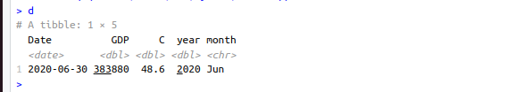

- Save the output into `output_table` folder with the name `first_summary` with `csv` extension.
  - *Hint:* `write.csv(d, 'folder/name.extension')`

*To do 4*

Use `pipe( %>% )`

- Select `Date`,`TOTAL` and `sector$Code` (All columns that have a code in `sector` dataset) from `gdp`.
  - Rename column `TOTAL` to `GDP` and create a new column named `GDP_in_1000` and drop the column `GDP`.
  - Filter the resulting data to have the most recent 10 years of the data and `GDP_in_1000` greater than 300.
    - *Hint:* `filter(year(Date) >= (year(max(Date))-10))`.
  - Assign `<-` the resulting data to `selected_df`. Use `head(selected_df)` to ensure you have a data that looks like the one below.

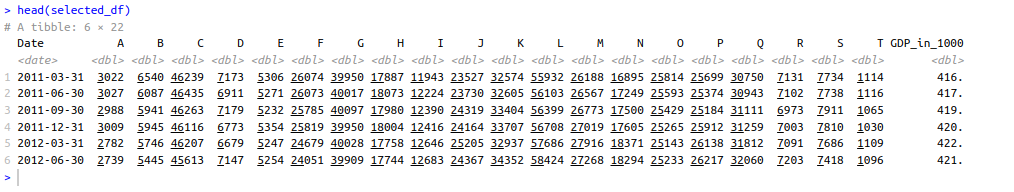

- Using the `selected_df` generated above, use pipe to pivot the dataset so that each observation is in a row using the function `pivot_longer()`.
  - *Hint:* `pivot_longer(cols = -c(Date), names_to = "Code", values_to = "Observation")`
- Left join the resulting data to `sector` dataset by `Code`
  - *Hint:* `left_join(sector, by = 'Code')`
- Mutate new variables called year which is the year of `Date` and month which is the month of `Date`
- Assigned the resulting dataset to `joined_df`.

We should have the following.

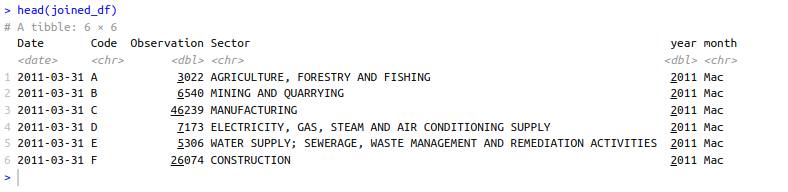

Save the resulting dataset in the `output_table` folder as a `csv` and name it `second_summary`

- Try to answer the following:
  - Which year did `AGRICULTURE, FORESTRY AND FISHING` sector had the largest observation?
  - Filter out `MANUFACTURING` and sum observations for each month.
  - Which year had the largest GDP?

*Run*

In preparation for our next session, execute the following code that will summarize the data needed for our data vizualization class.

```r
sectors = read.csv('data/Sectors.csv')
gdp = read_xlsx('data/GDPOutputData.xlsx', sheet = 'Data')

data_sectors <- gdp %>%
  select(Date, TOTAL, sectors$Code) %>%
  mutate(DE = D + E,
         AB = A + B) %>%
  pivot_longer(-Date, names_to = "Code", values_to = "Level") %>%
  left_join(sectors, by = "Code") %>%
  filter(!Code %in% c('A', 'B', 'D', 'E'))  %>%
  group_by(Code) %>%
  mutate(Date = as.Date(Date),
         QoQ = Level/lag(Level, 1)*100-100,
         YoY = Level/lag(Level, 4)*100-100)

write.csv(data_sectors, "output_table/data_sectors.csv")
```